# anna-AirBnB

### Welcome to the Airbnb Mini Practice Project

Throughout this unit on Python Data Analytics, you'be been introduced the the following powerful libraries:

Matplotlib

Seaborn

Pandas

Each of these libraries will enhance your data analysis capabilities.

We've created this challenging exercise to reinforce your understanding of how these libraries work.

Please note, there is a particular emphasis on the Pandas Library. This is the most critical Python library for data analytics. You'll see many similarities between Pandas and Pivot Tables!

**The most important thing you can do to build confidence with Python is to practice programming, all the time. This way you will build muscle memory. Don't simply copy the code you've written previously. Write it again and again so you store it in your memory.**

**As this is a practice exercise, we've included a copy of what the outputs *should* look like for the majority of the questions to give you some guidance.**

### Time to get started!

Import the airbnb_2.csv file.

Once you do this, you can start your analysis.

**Don't forget to import the libraries you need to read .csv files!**

### Step 1: Import Libraries

**Put your code in the box below.**

```python
import pandas as pd
import seaborn as sns
import matplotlib as plt
```

### Step 2: Import the Airbnb Dataset

Now that you have the Pandas Libraries imported, it's time to import the Airbnb dataset.

**i) Import the Airbnb dataset.**

ii) Use .info() function to better understand the variables inside your dataset.

**Put your code in the box below**

```python
pd.read_csv("airbnb_2.csv")
```

|  | id | name | host_id | host_name | neighbourhood_group | neighbourhood | latitude | longitude | room_type | price | minimum_nights | number_of_reviews | last_review | reviews_per_month | calculated_host_listings_count | availability_365 |
| --- | --- | --- | --- | --- | --- | --- | --- | --- | --- | --- | --- | --- | --- | --- | --- | --- |
| 0 | 2539 | Clean & quiet apt home by the park | 2787 | John | Brooklyn | Kensington | 40.64749 | -73.97237 | Private room | 149 | 1 | 9 | 19/10/2018 | 0.21 | 6 | 365 |
| 1 | 2595 | Skylit Midtown Castle | 2845 | Jennifer | Manhattan | Midtown | 40.75362 | -73.98377 | Entire home/apt | 225 | 1 | 45 | 21/05/2019 | 0.38 | 2 | 355 |
| 2 | 3647 | THE VILLAGE OF HARLEM....NEW YORK ! | 4632 | Elisabeth | Manhattan | Harlem | 40.80902 | -73.94190 | Private room | 150 | 3 | 0 | NaN | NaN | 1 | 365 |
| 3 | 3831 | Cozy Entire Floor of Brownstone | 4869 | LisaRoxanne | Brooklyn | Clinton Hill | 40.68514 | -73.95976 | Entire home/apt | 89 | 1 | 270 | 5/07/2019 | 4.64 | 1 | 194 |
| 4 | 5022 | Entire Apt: Spacious Studio/Loft by central park | 7192 | Laura | Manhattan | East Harlem | 40.79851 | -73.94399 | Entire home/apt | 80 | 10 | 9 | 19/11/2018 | 0.10 | 1 | 0 |
| ... | ... | ... | ... | ... | ... | ... | ... | ... | ... | ... | ... | ... | ... | ... | ... | ... |
| 48890 | 36484665 | Charming one bedroom - newly renovated rowhouse | 8232441 | Sabrina | Brooklyn | Bedford-Stuyvesant | 40.67853 | -73.94995 | Private room | 70 | 2 | 0 | NaN | NaN | 2 | 9 |
| 48891 | 36485057 | Affordable room in Bushwick/East Williamsburg | 6570630 | Marisol | Brooklyn | Bushwick | 40.70184 | -73.93317 | Private room | 40 | 4 | 0 | NaN | NaN | 2 | 36 |
| 48892 | 36485431 | Sunny Studio at Historical Neighborhood | 23492952 | Ilgar & Aysel | Manhattan | Harlem | 40.81475 | -73.94867 | Entire home/apt | 115 | 10 | 0 | NaN | NaN | 1 | 27 |
| 48893 | 36485609 | 43rd St. Time Square-cozy single bed | 30985759 | Taz | Manhattan | Hell's Kitchen | 40.75751 | -73.99112 | Shared room | 55 | 1 | 0 | NaN | NaN | 6 | 2 |
| 48894 | 36487245 | Trendy duplex in the very heart of Hell's Kitchen | 68119814 | Christophe | Manhattan | Hell's Kitchen | 40.76404 | -73.98933 | Private room | 90 | 7 | 0 | NaN | NaN | 1 | 23 |

48895 rows × 16 columns

```python
df=pd.read_csv("airbnb_2.csv")
print(df.info())
```

```
<class 'pandas.core.frame.DataFrame'>
RangeIndex: 48895 entries, 0 to 48894
Data columns (total 16 columns):
 #   Column                          Non-Null Count  Dtype
---  ------                          --------------  -----
 0   id                              48895 non-null  int64
 1   name                            48879 non-null  object
 2   host_id                         48895 non-null  int64
 3   host_name                       48874 non-null  object
 4   neighbourhood_group             48895 non-null  object
 5   neighbourhood                   48895 non-null  object
 6   latitude                        48895 non-null  float64
 7   longitude                       48895 non-null  float64
 8   room_type                       48895 non-null  object
 9   price                           48895 non-null  int64
 10  minimum_nights                  48895 non-null  int64
 11  number_of_reviews               48895 non-null  int64
 12  last_review                     38843 non-null  object
 13  reviews_per_month               38843 non-null  float64
 14  calculated_host_listings_count  48895 non-null  int64
 15  availability_365                48895 non-null  int64
dtypes: float64(3), int64(7), object(6)
memory usage: 6.0+ MB
None
```

### Step 3: Exploring your data with Pandas

The rest of these questions will have you focus on using the following Pandas Skills:

Subsetting a Pandas DataFrame using [] and boolean operators

Summing up records with value_counts()

Creating calculated fields

Group By in Pandas

Creating Bar Plots with Matplotlib

**i) Please count how many Airbnb listings are in each of the 5 Neighbourhood Groups (Manhattan, Brooklyn, Queens, Bronx, Staten Island), then identify which Neighbourhood Groups have the greatest number of Airbnb listings.**

**Put your code in the box below**

```python
ng= df.groupby(["neighbourhood_group"])["id"].count()
print(ng)
```

```
neighbourhood_group
Bronx             1091
Brooklyn         20104
Manhattan        21661
Queens            5666
Staten Island      373
Name: id, dtype: int64
```

We want to focus our attention on the 3 most popular Neighbourhood Groups, by listing volume.

**ii) Calculate the percentage of Airbnb listings that each Neighbourhood Group contains.**

See this resource for more details [.](https://pandas.pydata.org/pandas-docs/stable/reference/api/pandas.Series.value_counts.html)

**Put your code in the box below.**

```python
df["neighbourhood_group"].value_counts(normalize= True)
```

```
Manhattan        0.443011
Brooklyn         0.411167
Queens           0.115881
Bronx            0.022313
Staten Island    0.007629
Name: neighbourhood_group, dtype: float64
```

**iii) Create a new calculated field called Revenue and place this into the Airbnb DataFrame. This is to be calculated by using the Price Column x Number_Of_Reviews Columns**

**Put your code in the box below**

```python
df["Revenue"] = df["price"]*df["number_of_reviews"]
```

**iv) Create a Bar Plot that shows which Neighbourhood Group has the highest average revenues. In order to best calculate this, you'd want to consider how you can use the .groupby() syntax to assist you!**

If you're stuck, we recommend you go back to this [DataCamp link](https://learn.datacamp.com/courses/manipulating-dataframes-with-pandas). Specifically, Chapter 4 which covers how GROUP BY is used in Pandas.

**Put your code in the box below.**

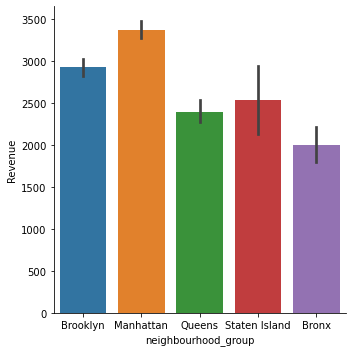

```python
sns.catplot(x= "neighbourhood_group", y= "Revenue", data= df, kind= "bar")
```

### Challenge Questions

**V) Filter the Airbnb DataFrame to include only the Neighbourhood Groups Manhattan, Brooklyn, and Queens.**

Then, identify the top 3 Revenue Generating Neighborhoods within each of the 3 Neighbourhood_Groups. This should give us 9 Overall Rows: 3 of the top generating neighbourhoods within each of the 3 Neighbourhood_Groups </b>

This is a tricky question that will *test* your group-by skills.

We recommend you consider the following:

```
condition1 = someDataFrame['someColumn']=='someCondition'
condition2 = someDataFrame['someColumn']=='someCondition'

Step One - Filter the DataFrame using the Conditions
filtered_dataframe = someDataFrame[condition1 OR condition 2]
#Hint: You might want to look up what the OR symbol in Python is represented as in operator form (i.e. AND (&) )

Step Two - Group the Data by Neighbourhood_Group and Neighbourhood. Don't forget you're looking to SUM up the Revenues.

The remaining steps we recommend you think very carefully about.

You might want to make use of the .reset_index(inplace=True) function to help reset the indexes in
your Grouped Up Dataframe...!
```

**Put your code in the box below.**

```python
mbq= df.groupby(["neighbourhood_group"])["Revenue"].sum()


step_one = df[(df["neighbourhood_group"] == "Manhattan") |
        (df["neighbourhood_group"] == "Brooklyn") |
        (df["neighbourhood_group"] == "Queens")]
step_two = step_one.groupby(['neighbourhood_group','neighbourhood']).sum()['Revenue'].sort_values(ascending=False)
step_three = pd.DataFrame(step_two)
step_four = step_three.reset_index().groupby(['neighbourhood_group']).head(3)
print(step_four)
```

```
   neighbourhood_group       neighbourhood   Revenue
0             Brooklyn        Williamsburg  12389011
1             Brooklyn  Bedford-Stuyvesant  12352457
2            Manhattan              Harlem   8598692
3            Manhattan      Hell's Kitchen   8238991
4            Manhattan        East Village   7574535
8             Brooklyn            Bushwick   4762224
17              Queens             Astoria   1880840
28              Queens    Long Island City   1374945
33              Queens            Flushing   1140450
```

# **VI) Filter the Airbnb Dataframe to include only the top 3 Neighbroos within each neighbourhood_group.**

After doing this, identify the top average revenue-generating room-type for each of the nine neighbourhoods and plot this in a Bar Chart.</b>

This is a tricky question that will *test* your group-by skills. Think back to the previous question and how you approached this; you can approach this in a similar manner.

We recommend you consider the following:

```
condition1 = someDataFrame['someColumn']=='someCondition'
condition2 = someDataFrame['someColumn']=='someCondition'

Step One - Filter the Dataframe using the Conditions
filtered_dataframe = someDataFrame[condition1 OR condition 2]
#Hint: You might want to look up what the OR symbol in Python is represented as in operator form (i.e. AND (&) )

Step Two - Group the Data by Neighbourhood_Group and Neighbourhood. Don't forget you're looking to SUM up the Revenues.

The remaining steps we recommend you think very carefully about.

You might want to make use of the .reset_index(inplace=True) function to help reset the indexes in
your Grouped Up Dataframe...!
```

**Put your code in the box below.**

```
AxesSubplot(0.125,0.125;0.775x0.755)
```

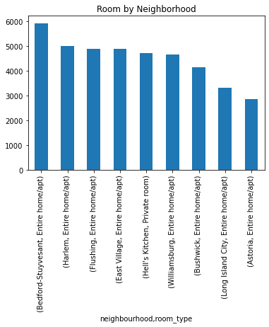

```python
roomy= df[(df ["neighbourhood"]=="Williamsburg")|(df ["neighbourhood"]=="Bedford-Stuyvesant") | (df["neighbourhood"]=="Harlem") |(df["neighbourhood"]=="Hell's Kitchen") | (df ["neighbourhood"]=="East Village") |(df ["neighbourhood"]=="Bushwick") | (df["neighbourhood"]=="Astoria") | (df ["neighbourhood"]=="Long Island City") | (df ["neighbourhood"]=="Flushing")].groupby(['neighbourhood','room_type']).mean().sort_values(by=['Revenue'],ascending=False)['Revenue'].groupby(['neighbourhood']).head(1).plot(kind='bar', title= "Room by Neighborhood")




print(roomy)
```